# Spatial model with INLA

Guillaume Blanchet & Steve Vissault

November 21th, 2019

# Introduction

This document was written to explain how to build univariate spatial model using INLA.

Note that INLA can be used with a range of data type because many different likelihood and link functions have been implemented in INLA. The different likelihood functions already implemented in INLA can be found by typing `INLA::inla.list.models("likelihood")` while the link functions can be found by typing `INLA::inla.list.models("link")`.

To illustrate how the models are constructed, the mite data will be used.

# Load R package for the analysis

```r
library(INLA)
library(raster)
library(vegan) # For the mite data
```

# Data

```r
data(mite)
data(mite.xy)
data(mite.env)
```

## Organize environmental data

```r
# Scale continuous variables
X <- scale(mite.env[,1:2])
```

## Sampling region

For our illustration, let’s also build a `SpatialPolygons` outlining the sampling area. This will become handy for a few steps when performing the analysis.

```r
poly <- Polygon(matrix(c(0,0,2.6,2.6,0,0,10,10,0,0),
                       nrow = 5, ncol = 2))
spacePoly <- SpatialPolygons(list(Polygons(list(poly),ID = 1)),
                             proj4string = crs("+proj=lcc +lat_1=60 +lat_2=46 +lat_0=44 +lon_0=-68.5 +x_0=0 +y_0=0 +datum=NAD83 +units=m +no_defs +ellps=GRS80 +towgs84=0,0,0"))
```

## Step 1 - Building the mesh

The first step that needs to be carried out to construct a spatially constrained model is to build a Delaunay triangulation, a mesh, that will serve as a basis to construct the spatial component of the model through an SPDE approach.

Properly choosing the structure of the mesh is essential for the model estimation to be carried out properly. Detailed explanation on the dos and don’ts of constructing a mesh is presented in section 1.3 of the [R-INLA tutorial on SPDE models](http://inla.r-inla-download.org/r-inla.org/tutorials/spde/html/). For a quick overview, take a look at the *mesh* practical. For our illustration, let’s use the following mesh.

```r
Mesh <- inla.mesh.2d(loc.domain = mite.xy, max.edge = 0.5,
                     min.angle = 20,
                     cutoff = 0.5,
                     offset = c(0.5,0.5),
                     crs = crs(spacePoly))
```

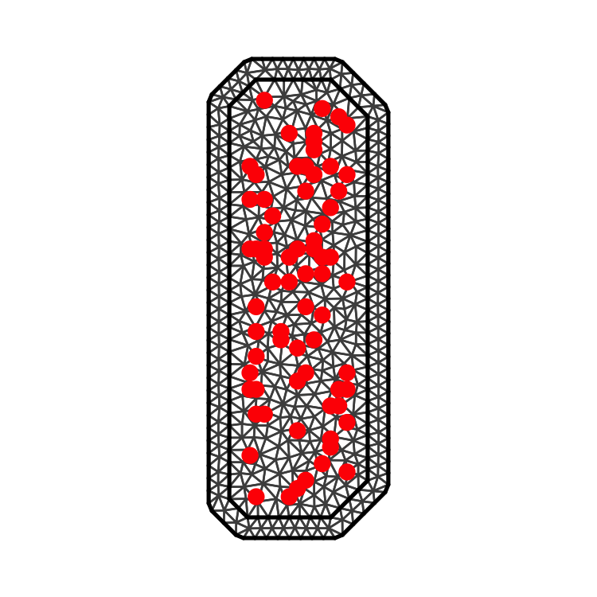

```r
par(mar = c(1,1,1,1))

plot(Mesh, main = "", asp = 1)
points(mite.xy, pch = 19, col = "red")
```

```r
# Number of edges in the mesh
Mesh$n
```

```
## [1] 589
```

## Step 2 - Define the stochastic partial differential equation object

This is important to define the structure of the field on which the spatial contrain is imposed. In some ways, this serves as our “model variogram”. Recall that in INLA, it is the Matérn model variogram that is used. In this respect, in addition of the mesh, we have to define the scaling parameter (`alpha`), the prior range (`prior.range`) and the prior variance (`prior.sigma`).

- `alpha`: This value needs to range between 0 and 2
- `prior.range`: This is a vector of length 2 specifying the range (first) and the uncertainty around this range (second). Note that the uncertainty around the range needs to be smaller that the range itself.
- `prior.sigma`: This is a vector of length 2 specifying the sill (first) and the uncertainty around this sill (second). Note that the uncertainty around the sill needs to be smaller that the range itself.

```r
SPDE <- inla.spde2.pcmatern(mesh=Mesh,
                            alpha=2,
                            prior.range=c(0.05, 0.01),
                            prior.sigma=c(1, 0.01))
```

### Step 3 - Index matrix

Here, we construct an “index matrix” used to extract the values of the latent spatial field at the observation locations.

```r
Field <- inla.spde.make.index("field",n.spde=Mesh$n)
```

### Step 4 - $A$ matrix

We need to construct $A$ matrices, one for estimation and another for predictions values. Recall from the lecture that the $A$ matrix is sometimes referred to as the *observation matrix* and includes the parameters used to construct model.

```r
# For estimation
AEst<-inla.spde.make.A(Mesh,loc=as.matrix(mite.xy))

# For prediction
APred<-inla.spde.make.A(Mesh)
```

### Step 5 - Organise the $A$ matrix into a list

```r
# For estimation
AEstlist <- list(AEst,1,1)

# For prediction
APredlist <- list(APred)
```

### Step 6 - Organise the effects (field and explanatory variables)

```r
# Estimation
effectEst <- list(i = 1:SPDE$n.spde,
                  SubsDens =  X[,1],
                  WatrCont = X[,2])

# Prediction
effectPred <- list(i = 1:SPDE$n.spde)
```

### Step 7 - Build `stack`

Here, we build a `stack` for estimation another for prediction and then we combine them together. Note that these are special version of `stack` especially designed for the INLA package.

```r
# Stack for estimation
StackEst <- inla.stack(data=list(mite = mite[,7]),
                     A = AEstlist,
                     effects = effectEst,
                     tag="est")

# Stack for prediction
StackPred <- inla.stack(data=list(mite = NA),
                        A=APredlist,
                        effects=effectPred,
                        tag="pred")

# Organise StackEst and StackPred into a single stack
Stack <- inla.stack(StackEst,StackPred)
```

### Step 8 - Building the model (Finally !)

```r
model <- inla(mite ~ 0 + SubsDens + WatrCont + f(i, model = SPDE),
              data = inla.stack.data(Stack),
              family="poisson",
              control.family =list(link="log"),
              control.predictor=list(A=inla.stack.A(Stack),
                                                         compute=TRUE, link = 1),
              control.compute=list(waic=TRUE))
```

### Study the output

```r
summary(model)
```

```
##
## Call:
##    c("inla(formula = mite ~ 0 + SubsDens + WatrCont + f(i, model = SPDE),
##    ", " family = \"poisson\", data = inla.stack.data(Stack),
##    control.compute = list(waic = TRUE), ", " control.predictor = list(A =
##    inla.stack.A(Stack), compute = TRUE, ", " link = 1), control.family =
##    list(link = \"log\"))")
## Time used:
##     Pre = 1.8, Running = 3.69, Post = 0.158, Total = 5.65
## Fixed effects:
##            mean    sd 0.025quant 0.5quant 0.975quant   mode kld
## SubsDens  0.854 0.190      0.492    0.850      1.239  0.842   0
## WatrCont -0.910 0.221     -1.350   -0.909     -0.473 -0.907   0
##
## Random effects:
##   Name     Model
##     i SPDE2 model
##
## Model hyperparameters:
##              mean    sd 0.025quant 0.5quant 0.975quant  mode
## Range for i 0.478 0.177      0.220    0.448      0.908 0.395
## Stdev for i 1.256 0.217      0.886    1.236      1.738 1.197
##
## Expected number of effective parameters(stdev): 31.75(3.07)
## Number of equivalent replicates : 2.21
##
## Watanabe-Akaike information criterion (WAIC) ...: 220.58
## Effective number of parameters .................: 25.13
##
## Marginal log-Likelihood:  -137.92
## Posterior marginals for the linear predictor and
##  the fitted values are computed
```

### Plot prediction maps

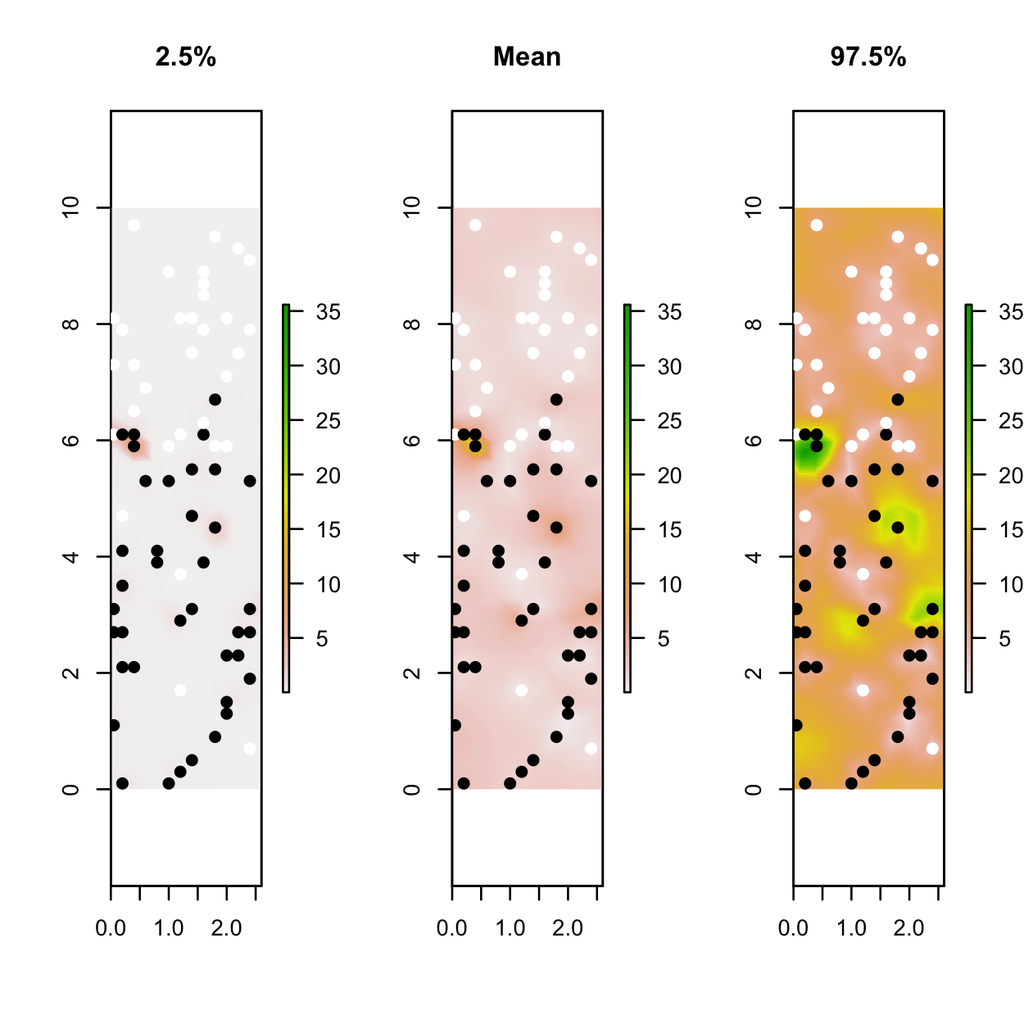

```r
# dimention of the raster
rasterDim <- c(2002, 520)

# Define basis of the map
mapBasis <- inla.mesh.projector(Mesh,
                               dims = rasterDim,
                               xlim = c(xmin(spacePoly), xmax(spacePoly)),
                               ylim = c(ymin(spacePoly), ymax(spacePoly)),
                               crs = crs(spacePoly))

# Find the mesh edges on which predictions should be made
ID <- inla.stack.index(Stack, tag="pred")$data

# Calculate prediction
mapMean <- inla.mesh.project(mapBasis,
                             model$summary.fitted.values[["mean"]][ID])
map.025 <- inla.mesh.project(mapBasis,
                             model$summary.fitted.values[["0.025quant"]][ID])
map.975 <- inla.mesh.project(mapBasis,
                             model$summary.fitted.values[["0.975quant"]][ID])

# Transform map into a raster
rasterMean <- raster(t(mapMean[,ncol(mapMean):1]),
                     xmn = min(mapBasis$x), xmx = max(mapBasis$x),
                     ymn = min(mapBasis$y), ymx = max(mapBasis$y))

raster.025 <- raster(t(map.025[,ncol(map.025):1]),
                     xmn = min(mapBasis$x), xmx = max(mapBasis$x),
                     ymn = min(mapBasis$y), ymx = max(mapBasis$y))

raster.975 <- raster(t(map.975[,ncol(map.975):1]),
                     xmn = min(mapBasis$x), xmx = max(mapBasis$x),
                     ymn = min(mapBasis$y), ymx = max(mapBasis$y))

# Plot the results
par(mfrow = c(1,3))
plot(raster.025, zlim = range(values(raster.025),
                              values(rasterMean),
                              values(raster.975)),
     main = "2.5%")

points(mite.xy, pch = 19, col = ifelse(mite[,7] > 0, "black", "white"))

plot(rasterMean, zlim = range(values(raster.025),
                              values(rasterMean),
                              values(raster.975)),
     main = "Mean")

points(mite.xy, pch = 19, col = ifelse(mite[,7] > 0, "black", "white"))

plot(raster.975, zlim = range(values(raster.025),
                              values(rasterMean),
                              values(raster.975)),
     main = "97.5%")

points(mite.xy, pch = 19, col = ifelse(mite[,7] > 0, "black", "white"))
```